# Analysis for Project

# Univariate distributions

Back to top

I created barplots to display the distributions of periods and feature types, as well as histograms of density.

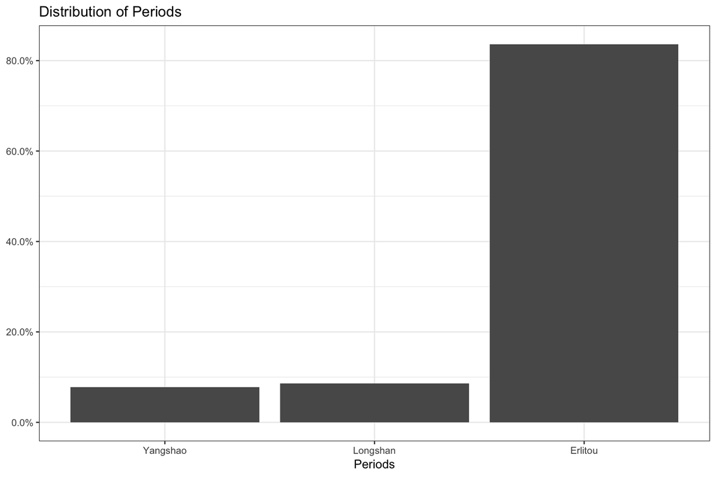

This barplot shows that there are three periods where the seeds are from–Yangshao, Longshan, and Erlitou. Most seed samples are from the Erlitou period (more than 80%). Yangshao and Longshan seeds constitute less than 10% of total seeds respectively, Yangshao has the smallest proportion among the three periods.

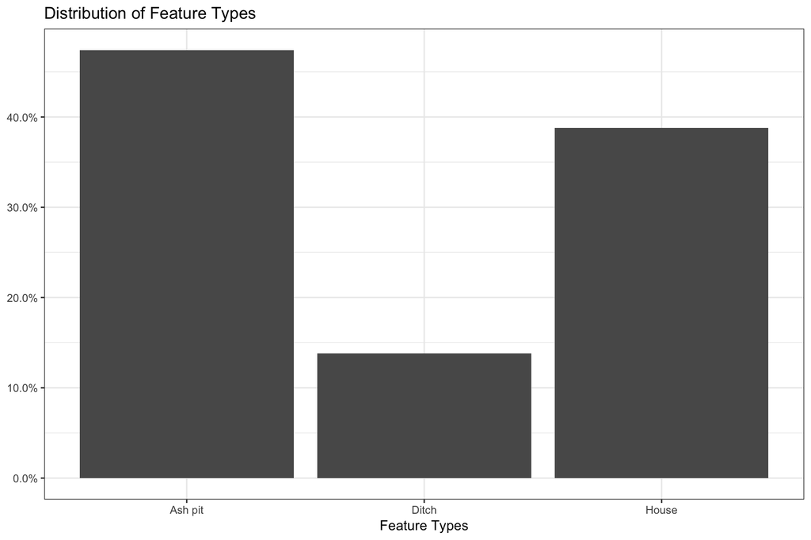

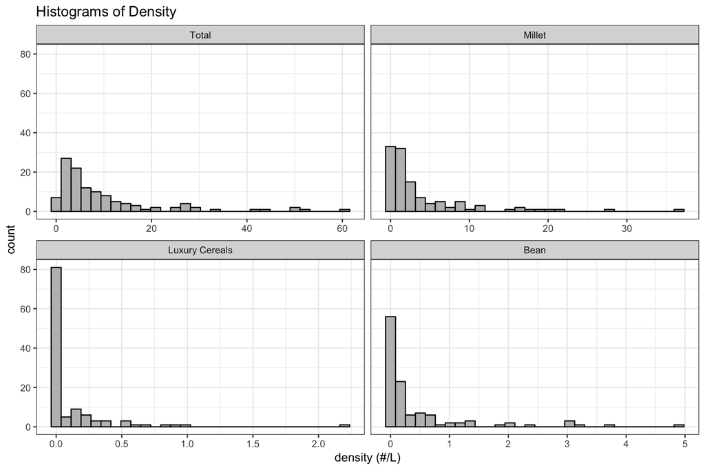

# Bivariate plots

Back to top

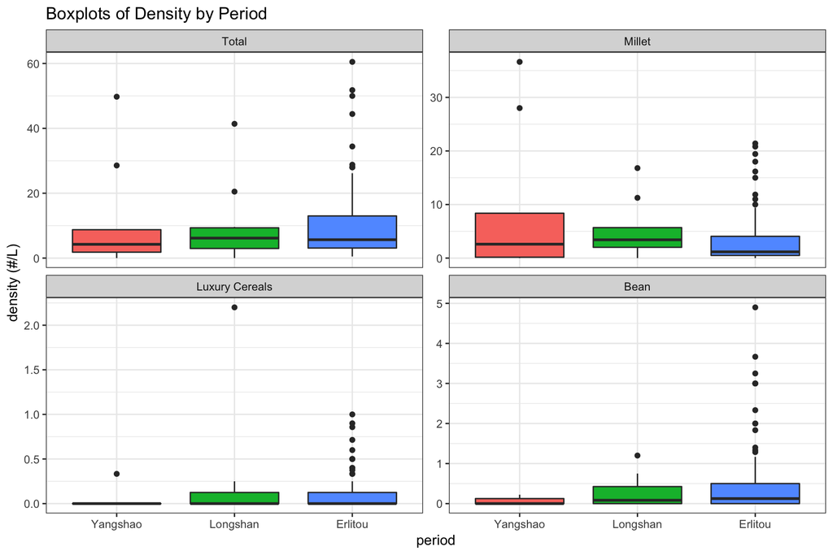

These boxplots show the densities of total seed, millet, luxury cereals, and bean by period. The y (density) scales of the four plots are very different, which means millets are the most common, and there are more beans found among the samples than luxury cereals. The total seed density boxplot has the highest densities among the three periods than other boxplots. The Yangshao period samples have the lowest 1st quartile and median, while the Erlitou period has the highest 3rd quartile and most outliers. This is understandable because the Erlitou samples constitute the largest proportion among the three periods. This is also the case for the luxury cereals density boxplot and the bean density boxplot. However, the Yangshao period seems to have the highest millet densities among the three.

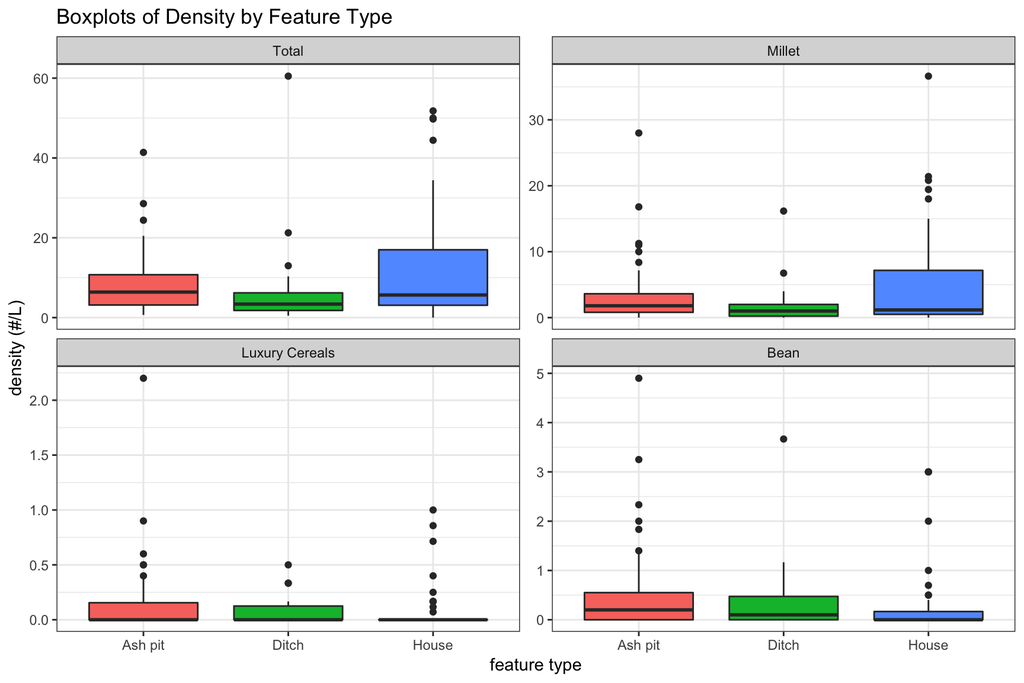

These boxplots show the densities of total seed, millet, luxury cereals, and bean by feature type. The y (density) scales of the four plots are very different, which means millets are the most common, and there are more beans found among the samples than luxury cereals. The total seed density boxplot has the highest densities among the three periods than other boxplots. House seems to be the feature from which most seeds especially millets are found. However, luxury cereals and beans are more commonly found in ash pits than in the other two feature types.

# Poisson models

Back to top

Quasi-poisson models of total seed densities by period and feature types

|  | **Model 1** | **Model 2** | **Model 3** | **Model 4** |  |
| --- | --- | --- | --- | --- | --- |
| Intercept | 2.56*** | 2.14*** | 2.50*** | 2.61*** |  |
|  | (0.31) | (0.16) | (0.34) | (0.42) |  |
| Longshan Period | -0.34 |  | -0.33 | -0.24 |  |
|  | (0.51) |  | (0.51) | (0.57) |  |
| Yangshao Period | -0.35 |  | -0.41 | -0.57 |  |
|  | (0.34) |  | (0.34) | (0.45) |  |
| Ditch |  | -0.05 | -0.09 | -2.18 |  |
|  |  | (0.38) | (0.39) | (1.72) |  |
| House |  | 0.28 | 0.30 | 0.55 |  |
|  |  | (0.23) | (0.23) | (0.60) |  |
| Yangshao:Ditch |  |  |  | 2.43 |  |
|  |  |  |  | (1.76) |  |
| Longshan:House |  |  |  | -1.88 |  |
|  |  |  |  | (1.76) |  |
| Yangshao:House |  |  |  | -0.21 |  |
|  |  |  |  | (0.65) |  |
| AIC |  |  |  |  |  |
| BIC |  |  |  |  |  |
| Log Likelihood |  |  |  |  |  |
| Deviance | 6909.27 | 6854.40 | 6746.87 | 6301.35 |  |
| Num. obs. | 116 | 116 | 116 | 116 |  |
| p < 0.001, p < 0.01, p < 0.05 |  |  |  |  |  |

For total seed densities as the dependent variable, I created four quasi-poisson models with different independent variables.

Model 1 has Period as the only independent variable. It shows that the Erlitou period soil samples have a total seed density of 12.93 #/L on average; the Longshan period samples have a total seed density of 29% less than Erlitou samples, on average; and the Yangshao period samples have a total seed density of 30% less than Erlitou samples, on average. Only the intercept is statistically significant.

Model 2 has feature types as the only independent variable. It shows that soil samples from ash pits have a total seed density of 8.5 #/L on average; samples from ditches have a total seed density of 5% less than ash pit samples, on average; and samples from houses have a total seed density of 32% more than ash pit samples, on average. Only the intercept is statistically significant.

Model 3 has both perid and feature types as independent variables. It shows that Erlitou soil samples from ash pits have a total seed density of 12.18 #/L on average. Within the same feature type, the Longshan period samples have a total seed density of 29% less than Erlitou samples, on average; and the Yangshao period samples have a total seed density of 34% less than Erlitou samples, on average. Within the same period, samples from ditches have a total seed density of 9% less than ash pit samples, on average; and samples from houses have a total seed density of 35% more than ash pit samples, on average. Only the intercept is statistically significant.

Quasi-poisson models of millet densities by period and feature types

|  | **Model 1** | **Model 2** | **Model 3** | **Model 4** |  |
| --- | --- | --- | --- | --- | --- |
| Intercept | 2.32*** | 1.23*** | 2.28*** | 2.44*** |  |
|  | (0.28) | (0.22) | (0.31) | (0.34) |  |
| Longshan Period | -0.78 |  | -0.84 | -0.80 |  |
|  | (0.52) |  | (0.51) | (0.54) |  |
| Yangshao Period | -1.16*** |  | -1.30*** | -1.61*** |  |
|  | (0.33) |  | (0.32) | (0.43) |  |
| Ditch |  | -0.43 | -0.61 | -2.88 |  |
|  |  | (0.62) | (0.55) | (1.99) |  |
| House |  | 0.40 | 0.48 | 0.41 |  |
|  |  | (0.31) | (0.27) | (0.51) |  |
| Yangshao:Ditch |  |  |  | 3.01 |  |
|  |  |  |  | (2.07) |  |
| Longshan:House |  |  |  | -1.26 |  |
|  |  |  |  | (1.54) |  |
| Yangshao:House |  |  |  | 0.24 |  |
|  |  |  |  | (0.61) |  |
| AIC |  |  |  |  |  |
| BIC |  |  |  |  |  |
| Log Likelihood |  |  |  |  |  |
| Deviance | 4349.47 | 4709.00 | 4054.35 | 3812.01 |  |
| Num. obs. | 116 | 116 | 116 | 116 |  |
| p < 0.001, p < 0.01, p < 0.05 |  |  |  |  |  |

For millet densities as the dependent variable, I created four quasi-poisson models with different independent variables.

Model 1 has Period as the only independent variable. It shows that the Erlitou period soil samples have a millet density of 10.17 #/L on average; the Longshan period samples have a millet density of 55% less than Erlitou samples, on average; and the Yangshao period samples have a millet density of 69% less than Erlitou samples, on average. Only the intercept and the coefficient of Yangshao period are statistically significant.

Model 2 has feature types as the only independent variable. It shows that soil samples from ash pits have a millet density of 3.42 #/L on average; samples from ditches have a millet density of 35% less than ash pit samples, on average; and samples from houses have a millet density of 49% more than ash pit samples, on average. Only the intercept is statistically significant.

Quasi-poisson models of luxury cereal densities by period and feature types

|  | **Model 1** | **Model 2** | **Model 3** | **Model 4** |  |
| --- | --- | --- | --- | --- | --- |
| Intercept | -3.08** | -2.02*** | -2.87** | -2.34* |  |
|  | (1.02) | (0.27) | (1.04) | (1.00) |  |
| Longshan Period | 1.61 |  | 1.47 | 1.06 |  |
|  | (1.13) |  | (1.15) | (1.10) |  |
| Yangshao Period | 0.77 |  | 0.77 | 0.16 |  |
|  | (1.04) |  | (1.05) | (1.04) |  |
| Ditch |  | -0.61 | -0.41 | -15.70 |  |
|  |  | (0.83) | (0.78) | (2090.63) |  |
| House |  | -0.56 | -0.49 | -16.11 |  |
|  |  | (0.51) | (0.48) | (2562.90) |  |
| Yangshao:Ditch |  |  |  | 15.48 |  |
|  |  |  |  | (2090.63) |  |
| Longshan:House |  |  |  | -0.51 |  |
|  |  |  |  | (3607.69) |  |
| Yangshao:House |  |  |  | 15.81 |  |
|  |  |  |  | (2562.90) |  |
| AIC |  |  |  |  |  |
| BIC |  |  |  |  |  |
| Log Likelihood |  |  |  |  |  |
| Deviance | 223.31 | 226.63 | 219.59 | 212.65 |  |
| Num. obs. | 116 | 116 | 116 | 116 |  |
| p < 0.001, p < 0.01, p < 0.05 |  |  |  |  |  |

For luxury cereal (LC) densities as the dependent variable, I created four quasi-poisson models with different independent variables.

Model 1 has Period as the only independent variable. It shows that the Erlitou period soil samples have a LC density of 0.04 #/L on average; the Longshan period samples have a LC density of 400% more than Erlitou samples, on average; and the Yangshao period samples have a LC density of 116% more than Erlitou samples, on average. Only the intercept is statistically significant.

Model 2 has feature types as the only independent variable. It shows that soil samples from ash pits have a LC density of 0.13 #/L on average; samples from ditches have a LC density of 46% less than ash pit samples, on average; and samples from houses have a LC density of 43% less than ash pit samples, on average. Only the intercept is statistically significant.

Model 3 has both perid and feature types as independent variables. It shows that Erlitou soil samples from ash pits have a LC density of 0.06 #/L on average. Within the same feature type, the Longshan period samples have a LC density of 335% more than Erlitou samples, on average; and the Yangshao period samples have a LC density of 116% more than Erlitou samples, on average. Within the same period, samples from ditches have a LC density of 34% less than ash pit samples, on average; and samples from houses have a LC density of 39% less than ash pit samples, on average. Only the intercept is statistically significant.

Quasi-poisson models of bean densities by period and feature types

|  | **Model 1** | **Model 2** | **Model 3** | **Model 4** |  |
| --- | --- | --- | --- | --- | --- |
| Intercept | -2.79 | -0.67** | -2.51 | -2.74 |  |
|  | (1.56) | (0.22) | (1.45) | (2.06) |  |
| Longshan Period | 1.32 |  | 1.18 | 1.30 |  |
|  | (1.78) |  | (1.65) | (2.24) |  |
| Yangshao Period | 1.90 |  | 2.00 | 2.24 |  |
|  | (1.57) |  | (1.45) | (2.07) |  |
| Ditch |  | -0.25 | -0.21 | -0.09 |  |
|  |  | (0.58) | (0.55) | (3.57) |  |
| House |  | -1.24* | -1.32* | -0.09 |  |
|  |  | (0.54) | (0.51) | (3.57) |  |
| Yangshao:Ditch |  |  |  | -0.13 |  |
|  |  |  |  | (3.61) |  |
| Longshan:House |  |  |  | -0.08 |  |
|  |  |  |  | (4.22) |  |
| Yangshao:House |  |  |  | -1.29 |  |
|  |  |  |  | (3.61) |  |
| AIC |  |  |  |  |  |
| BIC |  |  |  |  |  |
| Log Likelihood |  |  |  |  |  |
| Deviance | 641.71 | 609.56 | 569.28 | 566.59 |  |
| Num. obs. | 116 | 116 | 116 | 116 |  |
| p < 0.001, p < 0.01, p < 0.05 |  |  |  |  |  |

For bean densities as the dependent variable, I created four quasi-poisson models with different independent variables.

Model 1 has Period as the only independent variable. It shows that the Erlitou period soil samples have a bean density of 0.06 #/L on average; the Longshan period samples have a bean density of 274% more than Erlitou samples, on average; and the Yangshao period samples have a bean density of 569% more than Erlitou samples, on average. No coefficient is statistically significant.

Model 2 has feature types as the only independent variable. It shows that soil samples from ash pits have a bean density of 0.51 #/L on average; samples from ditches have a bean density of 23% less than ash pit samples, on average; and samples from houses have a bean density of 71% less than ash pit samples, on average. Only the intercept and the coefficient of House are statistically significant.

Model 3 has both perid and feature types as independent variables. It shows that Erlitou soil samples from ash pits have a bean density of 0.08 #/L on average. Within the same feature type, the Longshan period samples have a bean density of 225% more than Erlitou samples, on average; and the Yangshao period samples have a bean density of 639% more than Erlitou samples, on average. Within the same period, samples from ditches have a bean density of 19% less than ash pit samples, on average; and samples from houses have a bean density of 74% less than ash pit samples, on average. Only the coefficient of House is statistically significant.

Model 4 added the interaction between perid and feature types in addition to Model 3. It shows that Erlitou soil samples from ash pits have a bean density of 0.06 #/L on average. Among samples from ash pits, the Longshan period samples have a bean density of 267% more than Erlitou samples, on average; and the Yangshao period samples have a bean density of 839% more than Erlitou samples, on average. Among the Erlitou samples, samples from ditches have a bean density of 9% less than ash pit samples, on average; and samples from houses have a bean density of 9% less than ash pit samples, on average. Within the Yangshao period, ditch samples had a 20% lower bean density than ash pit samples. Within the Longshan period, house samples had a 16% lower bean density than ash pit samples. Within the Yangshao period, house samples had a 75% lower bean density than ash pit samples. No coefficient in Model 4 is statistically significant.